# What Our Wardrobes Reveal

## Does the brand really matter???

#### branded cloth is so expensive, as a college student I don’t have that much money to buy and also that amount of shoes.

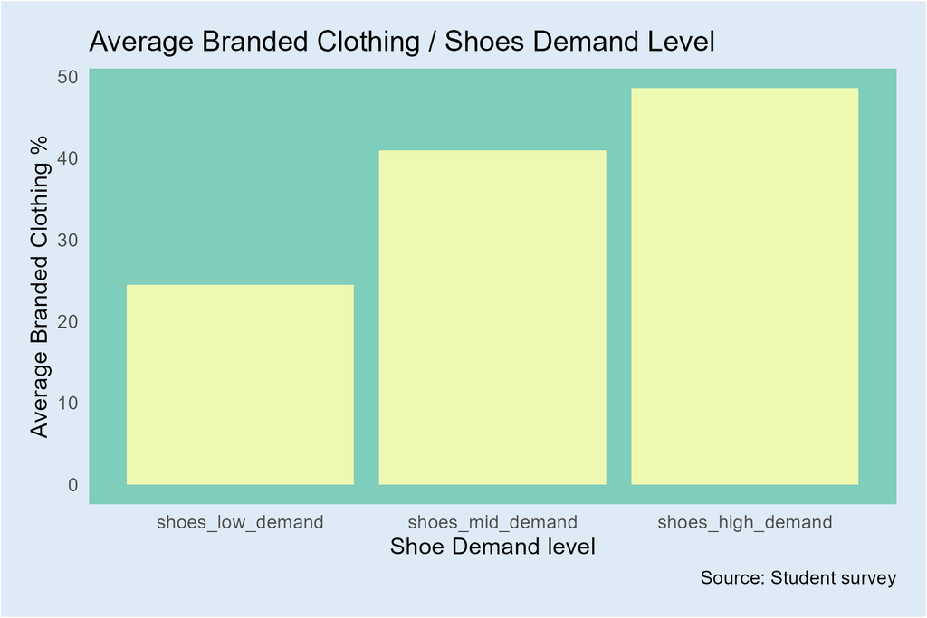

This bar chart illustrates how interest in branded clothing changes with different levels of shoe demand. The trend shows that as shoe demand increases, the average percentage of people wearing branded clothing also rises, suggesting a link between fashion interest and brand preference.

## NO wonder someone always stands out in crowd

#### Actually, I don’t really care what color my clothes are.

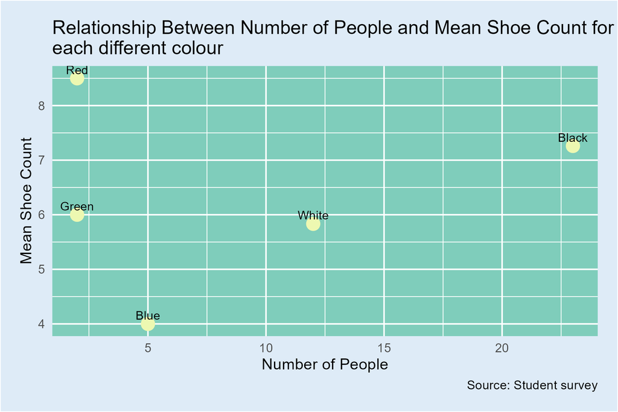

## How many shoes do you have???

#### Well, actually I want to ask why we have so many shoes when we only have two feet and so do I.

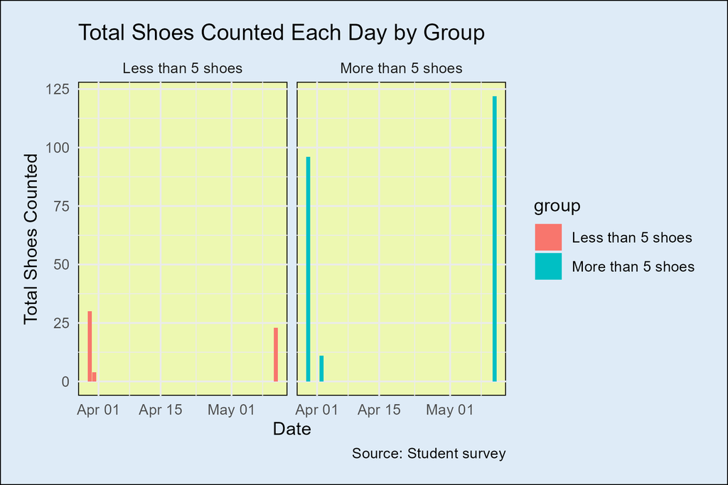

This faceted bar chart displays total shoes counted each day, categorized by demand groups. It highlights temporal patterns in shoe popularity, suggesting higher activity around the start of April and May, particularly for shoes classified as “More than 5 shoes.” Basically, It just means that the people who happened to ask that day had a lot of shoes. But for overall, the chart tell me that many people have many shoes.